# conda speed tests

John Blischak

2019-07-12 17:12:34

## Motivation

The conda package and environment manager is extremely useful. I’ve invested a lot of time maintaining R packages for the conda-forge channel and helping others adopt conda for their projects. However, recent versions have become extremely slow ([Issue #7239](https://github.com/conda/conda/issues/7239), [Issue #8291](https://github.com/conda/conda/issues/8291)). One advantage of conda over a more heavy weight option like Docker/singularity is that it is much easier to create new environments or add/remove specific packages, but this advantage is lost if it takes 30 minutes to install a package. I have been using conda to configure the environment for CI builds, but now the initial conda step either takes up most of the available CI time, or more often than not it stalls.

## Overview

I have created a GitHub repository conda-speed-tests and configured a [CircleCI workflow](https://circleci.com/gh/jdblischak/conda-speed-tests) to time conda commands for my common use cases.

```r
files <- dir_ls("log", glob = "*package_*.txt")
files_split <- str_split_fixed(files, "_", n = 3)
ids <- unique(files_split[, 2])
versions <- unique(str_replace(files_split[, 3], ".txt$", ""))
```

```r
list_instrument <- list()
```

```r
id <- ids[1]
for (v in versions) {
  instrument <- read.csv(glue::glue("log/instrumentation-record_{id}_{v}.csv"),
                         header = FALSE, stringsAsFactors = FALSE)
  instrument[["version"]] <- v
  list_instrument[[id]] <- rbind(list_instrument[[id]], instrument)
}
colnames(list_instrument[[id]]) <- c("step", "time", "version")
```

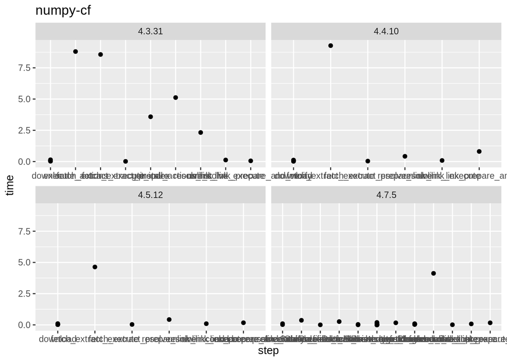

```r
ggplot(list_instrument[[id]], aes(x = step, y = time)) +
  geom_point() +
  facet_wrap(~version, scales = "free_x") +
  labs(title = id)
```

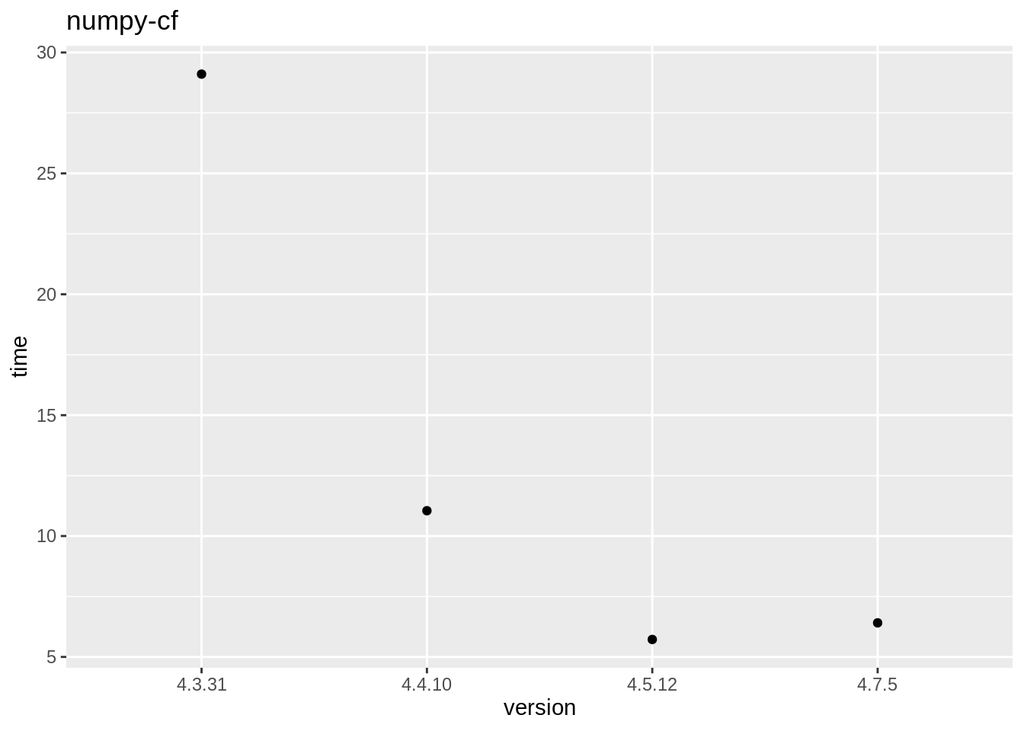

```r
total <- list_instrument[[id]] %>%
  group_by(version) %>%
  summarize(time = sum(time))
ggplot(total, aes(x = version, y = time)) +
  geom_point() +
  labs(title = id)
```

```r
config <- readLines(glue::glue("log/conda-config_{id}_{v}.txt"))
config <- paste(config, collapse = "\n")
glue::glue("
<details>
<summary>
Output of <code>conda config --show-sources</code>
</summary>
<code>
{config}
</code>
</details>
"
)
```

**Output of `conda config –show-sources`**

`==> /root/.condarc <== auto_update_conda: False changeps1: False channels: - conda-forge - defaults always_yes: True quiet: True`